# No Show Appointment Data Analysis

- Introduction
- Data Wrangling
- Exploratory Data Analysis
- Conclusions

### Questions:

- Which gender misses their appointments the most?
- Do more people that receive a message arrive for their appointments?
- Do patients with hypertension attend their appointments

## Introduction

> In this project we will be analysing data on various reasons in which patients are not present for their appointments.

```python
# Use this cell to set up import statements for all of the packages that you
#   plan to use.

import pandas as pd
import numpy as np
import seaborn as sns
import matplotlib.pyplot as plt

%matplotlib inline
```

## Data Wrangling

### General Properties

```python
# We will load the data set
df = pd.read_csv('noshowappointments-kagglev2-may-2016.csv')
df.head()
```

|  | PatientId | AppointmentID | Gender | ScheduledDay | AppointmentDay | Age | Neighbourhood | Scholarship | Hipertension | Diabetes | Alcoholism | Handcap | SMS_received | No-show |
| --- | --- | --- | --- | --- | --- | --- | --- | --- | --- | --- | --- | --- | --- | --- |
| 0 | 2.987250e+13 | 5642903 | F | 2016-04-29T18:38:08Z | 2016-04-29T00:00:00Z | 62 | JARDIM DA PENHA | 0 | 1 | 0 | 0 | 0 | 0 | No |
| 1 | 5.589978e+14 | 5642503 | M | 2016-04-29T16:08:27Z | 2016-04-29T00:00:00Z | 56 | JARDIM DA PENHA | 0 | 0 | 0 | 0 | 0 | 0 | No |
| 2 | 4.262962e+12 | 5642549 | F | 2016-04-29T16:19:04Z | 2016-04-29T00:00:00Z | 62 | MATA DA PRAIA | 0 | 0 | 0 | 0 | 0 | 0 | No |
| 3 | 8.679512e+11 | 5642828 | F | 2016-04-29T17:29:31Z | 2016-04-29T00:00:00Z | 8 | PONTAL DE CAMBURI | 0 | 0 | 0 | 0 | 0 | 0 | No |
| 4 | 8.841186e+12 | 5642494 | F | 2016-04-29T16:07:23Z | 2016-04-29T00:00:00Z | 56 | JARDIM DA PENHA | 0 | 1 | 1 | 0 | 0 | 0 | No |

```python
# Checking for datatypes
df.dtypes
```

```
PatientId         float64
AppointmentID       int64
Gender             object
ScheduledDay       object
AppointmentDay     object
Age                 int64
Neighbourhood      object
Scholarship         int64
Hipertension        int64
Diabetes            int64
Alcoholism          int64
Handcap             int64
SMS_received        int64
No-show            object
dtype: object
```

```python
# Checking for the min, max and mean of each column
df.describe()
```

|  | PatientId | AppointmentID | Age | Scholarship | Hipertension | Diabetes | Alcoholism | Handcap | SMS_received |
| --- | --- | --- | --- | --- | --- | --- | --- | --- | --- |
| count | 1.105270e+05 | 1.105270e+05 | 110527.000000 | 110527.000000 | 110527.000000 | 110527.000000 | 110527.000000 | 110527.000000 | 110527.000000 |
| mean | 1.474963e+14 | 5.675305e+06 | 37.088874 | 0.098266 | 0.197246 | 0.071865 | 0.030400 | 0.022248 | 0.321026 |
| std | 2.560949e+14 | 7.129575e+04 | 23.110205 | 0.297675 | 0.397921 | 0.258265 | 0.171686 | 0.161543 | 0.466873 |
| min | 3.921784e+04 | 5.030230e+06 | -1.000000 | 0.000000 | 0.000000 | 0.000000 | 0.000000 | 0.000000 | 0.000000 |
| 25% | 4.172614e+12 | 5.640286e+06 | 18.000000 | 0.000000 | 0.000000 | 0.000000 | 0.000000 | 0.000000 | 0.000000 |
| 50% | 3.173184e+13 | 5.680573e+06 | 37.000000 | 0.000000 | 0.000000 | 0.000000 | 0.000000 | 0.000000 | 0.000000 |
| 75% | 9.439172e+13 | 5.725524e+06 | 55.000000 | 0.000000 | 0.000000 | 0.000000 | 0.000000 | 0.000000 | 1.000000 |
| max | 9.999816e+14 | 5.790484e+06 | 115.000000 | 1.000000 | 1.000000 | 1.000000 | 1.000000 | 4.000000 | 1.000000 |

```python
# Checking for information about the data set
df.info()
```

```
<class 'pandas.core.frame.DataFrame'>
RangeIndex: 110527 entries, 0 to 110526
Data columns (total 14 columns):
 #   Column          Non-Null Count   Dtype
---  ------          --------------   -----
 0   PatientId       110527 non-null  float64
 1   AppointmentID   110527 non-null  int64
 2   Gender          110527 non-null  object
 3   ScheduledDay    110527 non-null  object
 4   AppointmentDay  110527 non-null  object
 5   Age             110527 non-null  int64
 6   Neighbourhood   110527 non-null  object
 7   Scholarship     110527 non-null  int64
 8   Hipertension    110527 non-null  int64
 9   Diabetes        110527 non-null  int64
 10  Alcoholism      110527 non-null  int64
 11  Handcap         110527 non-null  int64
 12  SMS_received    110527 non-null  int64
 13  No-show         110527 non-null  object
dtypes: float64(1), int64(8), object(5)
memory usage: 11.8+ MB
```

### Data Cleaning

```python
# We are going to be dropping the patient id and appointment id because it is unique to each patient.
df.drop(['PatientId', 'AppointmentID'], axis = 1, inplace = True)
```

```python
# Checking if it has been deleted
df.columns
```

```
Index(['Gender', 'ScheduledDay', 'AppointmentDay', 'Age', 'Neighbourhood',
       'Scholarship', 'Hipertension', 'Diabetes', 'Alcoholism', 'Handcap',
       'SMS_received', 'No-show'],
      dtype='object')
```

```python
# we are going to remove the row that has age as -1, because it is not possible for someone's age to be -1
df.drop([99832], axis = 0, inplace = True)
```

```python
# Checking if row with -1 is still there
df[df.Age  == -1]
```

|  | Gender | ScheduledDay | AppointmentDay | Age | Neighbourhood | Scholarship | Hipertension | Diabetes | Alcoholism | Handcap | SMS_received | No-show |
| --- | --- | --- | --- | --- | --- | --- | --- | --- | --- | --- | --- | --- |

```python
# Check for null values.
df.isnull().sum().any()
```

```
False
```

```python
# Checking for duplicates
df.duplicated().sum()
```

```
635
```

```python
# we are going to drop duplicates
df.drop_duplicates(inplace = True)
```

```python
# Checking if changes have been made and there are no duplicates
df.duplicated().sum()
```

```
0
```

```python
# We are also going to be changing the yes and no in the no show column to 1 and 0 for easy analysis
df['No-show'].replace(['No', 'Yes'], ['0', '1'], inplace = True)
```

```python
# Checking if changes have been made
df.head()
```

|  | Gender | ScheduledDay | AppointmentDay | Age | Neighbourhood | Scholarship | Hipertension | Diabetes | Alcoholism | Handcap | SMS_received | No-show |
| --- | --- | --- | --- | --- | --- | --- | --- | --- | --- | --- | --- | --- |
| 0 | F | 2016-04-29T18:38:08Z | 2016-04-29T00:00:00Z | 62 | JARDIM DA PENHA | 0 | 1 | 0 | 0 | 0 | 0 | 0 |
| 1 | M | 2016-04-29T16:08:27Z | 2016-04-29T00:00:00Z | 56 | JARDIM DA PENHA | 0 | 0 | 0 | 0 | 0 | 0 | 0 |
| 2 | F | 2016-04-29T16:19:04Z | 2016-04-29T00:00:00Z | 62 | MATA DA PRAIA | 0 | 0 | 0 | 0 | 0 | 0 | 0 |
| 3 | F | 2016-04-29T17:29:31Z | 2016-04-29T00:00:00Z | 8 | PONTAL DE CAMBURI | 0 | 0 | 0 | 0 | 0 | 0 | 0 |
| 4 | F | 2016-04-29T16:07:23Z | 2016-04-29T00:00:00Z | 56 | JARDIM DA PENHA | 0 | 1 | 1 | 0 | 0 | 0 | 0 |

```python
# We want to change the no-show column to integer
df['No-show'] = df['No-show'].astype(int)
```

```python
# Verifying the datatype of No-show
df.dtypes
```

```
Gender            object
ScheduledDay      object
AppointmentDay    object
Age                int64
Neighbourhood     object
Scholarship        int64
Hipertension       int64
Diabetes           int64
Alcoholism         int64
Handcap            int64
SMS_received       int64
No-show            int32
dtype: object
```

## Exploratory Data Analysis

### Which gender missed their appointments the most

```python
# Checking for which gender missed their appointment the most using groupby
mean = df.groupby('Gender')['No-show'].mean()
mean
```

```
Gender
F    0.202406
M    0.198648
Name: No-show, dtype: float64
```

```python
# Wriring a function for plotting the graph

def bar_plot(choice_1, choice_2, title, x_label, y_label):
    plt.bar([0 , 1], mean, tick_label = [choice_1, choice_2])
    plt.title(title)
    plt.xlabel(x_label)
    plt.ylabel(y_label);
```

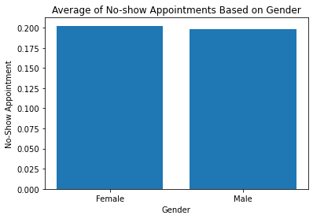

```python
# Plotting a bar graph
bar_plot('Female', 'Male', 'Average of No-show Appointments Based on Gender', 'Gender', 'No-Show Appointment');
```

> From this bar chart we can see that females show up less compared to men

### Do more people that receive a message arrive for their appointments

```python
# Checking if sending messages influenced patients choice to go for appointment using groupby
mean = df.groupby('SMS_received')['No-show'].mean()
mean
```

```
SMS_received
0    0.165491
1    0.275745
Name: No-show, dtype: float64
```

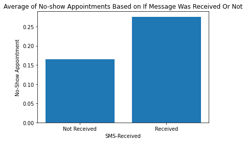

```python
# Plotting a bar graph
bar_plot('Not Received', 'Received', 'Average of No-show Appointments Based on If Message Was Received Or Not', 'SMS-Received', 'No-Show Appointment');
```

> From this bar chart we can see that less people came when they received a message.

### Question 3: Do patients with hypertension attend their appointments

```python
# Checking for the strength of relationship between hypertension and no show
df.corr().Hipertension['No-show']
```

```
-0.035992136154651834
```

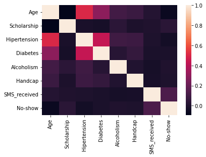

```python
# Plotting a heat map
sns.heatmap(df.corr());
```

> From the heatmap we are able to conclude that there is no correlation between hypertension and no-show. This means that them having hypertension does not necessarily mean that they will come for their appointments

## Conclusions

> So from the first question, we were able to deduce the fact that more females missed their appointment compared to the males.

> From the second question, we were able to deduce that sending a message to the patient does not necessarily mean that they will attend to their appointment.

> From the third question, we are able to deduce that people having hypertension does not necessarily mean that they will show for their appointments

## Limitation

> Dropping the column with age of -1 can distort accuracy due to the fact that the age might have been an error during entry